# Risk Factor Analysis

## Outcome Variable

**Outcome Variable:** wast_rec90d

## Predictor Variables

**Intervention Variable:** earlybf

**Adjustment Set:**

unadjusted

## Stratifying Variables

The analysis was stratified on these variable(s):

- agecat
- studyid
- country

## Data Summary

| agecat | studyid | country | earlybf | wast_rec90d | n_cell | n |
| --- | --- | --- | --- | --- | --- | --- |
| 0-24 months | EE | PAKISTAN | 1 | 0 | 25 | 314 |
| 0-24 months | EE | PAKISTAN | 1 | 1 | 30 | 314 |
| 0-24 months | EE | PAKISTAN | 0 | 0 | 130 | 314 |
| 0-24 months | EE | PAKISTAN | 0 | 1 | 129 | 314 |
| 0-24 months | GMS-Nepal | NEPAL | 1 | 0 | 67 | 582 |
| 0-24 months | GMS-Nepal | NEPAL | 1 | 1 | 94 | 582 |
| 0-24 months | GMS-Nepal | NEPAL | 0 | 0 | 199 | 582 |
| 0-24 months | GMS-Nepal | NEPAL | 0 | 1 | 222 | 582 |
| 0-24 months | JiVitA-3 | BANGLADESH | 1 | 0 | 43 | 7562 |
| 0-24 months | JiVitA-3 | BANGLADESH | 1 | 1 | 13 | 7562 |
| 0-24 months | JiVitA-3 | BANGLADESH | 0 | 0 | 4323 | 7562 |
| 0-24 months | JiVitA-3 | BANGLADESH | 0 | 1 | 3183 | 7562 |
| 0-24 months | JiVitA-4 | BANGLADESH | 1 | 0 | 958 | 2069 |
| 0-24 months | JiVitA-4 | BANGLADESH | 1 | 1 | 357 | 2069 |
| 0-24 months | JiVitA-4 | BANGLADESH | 0 | 0 | 576 | 2069 |
| 0-24 months | JiVitA-4 | BANGLADESH | 0 | 1 | 178 | 2069 |
| 0-24 months | MAL-ED | BANGLADESH | 1 | 0 | 25 | 122 |
| 0-24 months | MAL-ED | BANGLADESH | 1 | 1 | 46 | 122 |
| 0-24 months | MAL-ED | BANGLADESH | 0 | 0 | 18 | 122 |
| 0-24 months | MAL-ED | BANGLADESH | 0 | 1 | 33 | 122 |
| 0-24 months | MAL-ED | BRAZIL | 1 | 0 | 3 | 24 |
| 0-24 months | MAL-ED | BRAZIL | 1 | 1 | 6 | 24 |
| 0-24 months | MAL-ED | BRAZIL | 0 | 0 | 3 | 24 |
| 0-24 months | MAL-ED | BRAZIL | 0 | 1 | 12 | 24 |
| 0-24 months | MAL-ED | INDIA | 1 | 0 | 44 | 181 |
| 0-24 months | MAL-ED | INDIA | 1 | 1 | 63 | 181 |
| 0-24 months | MAL-ED | INDIA | 0 | 0 | 27 | 181 |
| 0-24 months | MAL-ED | INDIA | 0 | 1 | 47 | 181 |
| 0-24 months | MAL-ED | NEPAL | 1 | 0 | 9 | 98 |
| 0-24 months | MAL-ED | NEPAL | 1 | 1 | 33 | 98 |

[output cut: 138 more lines]

The following strata were considered:

- agecat: 0-24 months, studyid: EE, country: PAKISTAN
- agecat: 0-24 months, studyid: GMS-Nepal, country: NEPAL
- agecat: 0-24 months, studyid: JiVitA-3, country: BANGLADESH
- agecat: 0-24 months, studyid: JiVitA-4, country: BANGLADESH
- agecat: 0-24 months, studyid: MAL-ED, country: BANGLADESH
- agecat: 0-24 months, studyid: MAL-ED, country: BRAZIL
- agecat: 0-24 months, studyid: MAL-ED, country: INDIA
- agecat: 0-24 months, studyid: MAL-ED, country: NEPAL
- agecat: 0-24 months, studyid: MAL-ED, country: PERU
- agecat: 0-24 months, studyid: MAL-ED, country: SOUTH AFRICA
- agecat: 0-24 months, studyid: MAL-ED, country: TANZANIA, UNITED REPUBLIC OF
- agecat: 0-24 months, studyid: NIH-Crypto, country: BANGLADESH
- agecat: 0-24 months, studyid: SAS-CompFeed, country: INDIA
- agecat: 0-24 months, studyid: ZVITAMBO, country: ZIMBABWE
- agecat: 0-6 months, studyid: EE, country: PAKISTAN
- agecat: 0-6 months, studyid: GMS-Nepal, country: NEPAL
- agecat: 0-6 months, studyid: JiVitA-3, country: BANGLADESH
- agecat: 0-6 months, studyid: JiVitA-4, country: BANGLADESH
- agecat: 0-6 months, studyid: MAL-ED, country: BANGLADESH
- agecat: 0-6 months, studyid: MAL-ED, country: BRAZIL
- agecat: 0-6 months, studyid: MAL-ED, country: INDIA
- agecat: 0-6 months, studyid: MAL-ED, country: NEPAL
- agecat: 0-6 months, studyid: MAL-ED, country: PERU
- agecat: 0-6 months, studyid: MAL-ED, country: SOUTH AFRICA
- agecat: 0-6 months, studyid: MAL-ED, country: TANZANIA, UNITED REPUBLIC OF
- agecat: 0-6 months, studyid: NIH-Crypto, country: BANGLADESH
- agecat: 0-6 months, studyid: SAS-CompFeed, country: INDIA
- agecat: 0-6 months, studyid: ZVITAMBO, country: ZIMBABWE
- agecat: 6-24 months, studyid: EE, country: PAKISTAN
- agecat: 6-24 months, studyid: GMS-Nepal, country: NEPAL
- agecat: 6-24 months, studyid: JiVitA-3, country: BANGLADESH
- agecat: 6-24 months, studyid: JiVitA-4, country: BANGLADESH
- agecat: 6-24 months, studyid: MAL-ED, country: BANGLADESH
- agecat: 6-24 months, studyid: MAL-ED, country: BRAZIL
- agecat: 6-24 months, studyid: MAL-ED, country: INDIA
- agecat: 6-24 months, studyid: MAL-ED, country: NEPAL
- agecat: 6-24 months, studyid: MAL-ED, country: PERU
- agecat: 6-24 months, studyid: MAL-ED, country: SOUTH AFRICA
- agecat: 6-24 months, studyid: MAL-ED, country: TANZANIA, UNITED REPUBLIC OF
- agecat: 6-24 months, studyid: NIH-Crypto, country: BANGLADESH
- agecat: 6-24 months, studyid: SAS-CompFeed, country: INDIA
- agecat: 6-24 months, studyid: ZVITAMBO, country: ZIMBABWE

### Dropped Strata

Some strata were dropped due to rare outcomes:

- agecat: 0-24 months, studyid: MAL-ED, country: BRAZIL
- agecat: 0-24 months, studyid: MAL-ED, country: PERU
- agecat: 0-24 months, studyid: MAL-ED, country: TANZANIA, UNITED REPUBLIC OF
- agecat: 0-6 months, studyid: MAL-ED, country: BRAZIL
- agecat: 0-6 months, studyid: MAL-ED, country: NEPAL
- agecat: 0-6 months, studyid: MAL-ED, country: PERU
- agecat: 0-6 months, studyid: MAL-ED, country: SOUTH AFRICA
- agecat: 0-6 months, studyid: MAL-ED, country: TANZANIA, UNITED REPUBLIC OF
- agecat: 6-24 months, studyid: JiVitA-3, country: BANGLADESH
- agecat: 6-24 months, studyid: MAL-ED, country: BRAZIL
- agecat: 6-24 months, studyid: MAL-ED, country: NEPAL
- agecat: 6-24 months, studyid: MAL-ED, country: PERU
- agecat: 6-24 months, studyid: MAL-ED, country: SOUTH AFRICA
- agecat: 6-24 months, studyid: MAL-ED, country: TANZANIA, UNITED REPUBLIC OF
- agecat: 6-24 months, studyid: NIH-Crypto, country: BANGLADESH

## Methods Detail

We’re interested in the causal parameters $E[Y_a]$ for all values of $a \in \mathcal{A}$. These parameters represent the mean outcome if, possibly contrary to fact, we intervened to set all units to have $A=a$. Under the randomization and positivity assumptions, these are identified by the statistical parameters $\psi_a=E_W[E_{Y|A,W}(Y|A=a,W)]$. In addition, we’re interested in the mean of $Y$, $E[Y]$ under no intervention (the observed mean). We will estimate these parameters by using SuperLearner to fit the relevant likelihood factors – $E_{Y|A,W}(Y|A=a,W)$ and $p(A=a|W)$, and then updating our likelihood fit using a joint TMLE.

For unadjusted analyses ($W=\{\}$), initial likelihoods were estimated using Lrnr_glm to estimate the simple $E(Y|A)$ and Lrnr_mean to estimate $p(A)$. For adjusted analyses, a small library containing Lrnr_glmnet, Lrnr_xgboost, and Lrnr_mean was used.

Having estimated these parameters, we will then use the delta method to estimate relative risks and attributable risks relative to a prespecified baseline level of $A$.

# Results Detail

## Results Plots

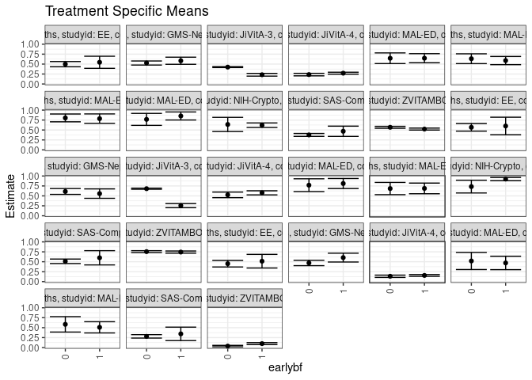

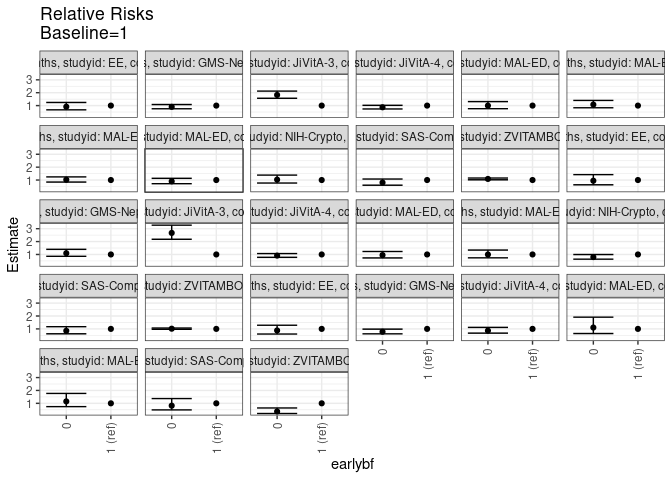

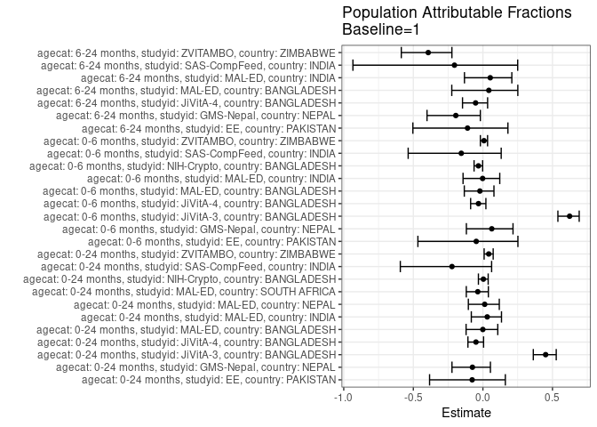

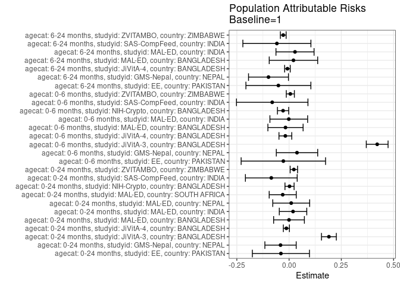

## Results Table

### Parameter: TSM

| agecat | studyid | country | intervention_level | baseline_level | estimate | ci_lower | ci_upper |
| --- | --- | --- | --- | --- | --- | --- | --- |
| 0-24 months | EE | PAKISTAN | 1 | NA | 0.5454545 | 0.3932783 | 0.6976308 |
| 0-24 months | EE | PAKISTAN | 0 | NA | 0.4980695 | 0.4328978 | 0.5632412 |
| 0-24 months | GMS-Nepal | NEPAL | 1 | NA | 0.5838509 | 0.4941187 | 0.6735832 |
| 0-24 months | GMS-Nepal | NEPAL | 0 | NA | 0.5273159 | 0.4761926 | 0.5784393 |
| 0-24 months | JiVitA-3 | BANGLADESH | 1 | NA | 0.2321429 | 0.1975164 | 0.2667693 |
| 0-24 months | JiVitA-3 | BANGLADESH | 0 | NA | 0.4240608 | 0.4126893 | 0.4354322 |
| 0-24 months | JiVitA-4 | BANGLADESH | 1 | NA | 0.2714829 | 0.2469755 | 0.2959902 |
| 0-24 months | JiVitA-4 | BANGLADESH | 0 | NA | 0.2360743 | 0.2047360 | 0.2674126 |
| 0-24 months | MAL-ED | BANGLADESH | 1 | NA | 0.6478873 | 0.5335441 | 0.7622306 |
| 0-24 months | MAL-ED | BANGLADESH | 0 | NA | 0.6470588 | 0.5134843 | 0.7806334 |
| 0-24 months | MAL-ED | INDIA | 1 | NA | 0.5887850 | 0.4860308 | 0.6915393 |
| 0-24 months | MAL-ED | INDIA | 0 | NA | 0.6351351 | 0.5117449 | 0.7585253 |
| 0-24 months | MAL-ED | NEPAL | 1 | NA | 0.7857143 | 0.6676859 | 0.9037426 |
| 0-24 months | MAL-ED | NEPAL | 0 | NA | 0.8035714 | 0.7055573 | 0.9015856 |
| 0-24 months | MAL-ED | SOUTH AFRICA | 1 | NA | 0.8518519 | 0.7511196 | 0.9525841 |
| 0-24 months | MAL-ED | SOUTH AFRICA | 0 | NA | 0.7666667 | 0.6158718 | 0.9174615 |
| 0-24 months | NIH-Crypto | BANGLADESH | 1 | NA | 0.6204380 | 0.5638068 | 0.6770691 |
| 0-24 months | NIH-Crypto | BANGLADESH | 0 | NA | 0.6388889 | 0.4604042 | 0.8173735 |
| 0-24 months | SAS-CompFeed | INDIA | 1 | NA | 0.4677419 | 0.3388388 | 0.5966451 |
| 0-24 months | SAS-CompFeed | INDIA | 0 | NA | 0.3756684 | 0.3390824 | 0.4122545 |
| 0-24 months | ZVITAMBO | ZIMBABWE | 1 | NA | 0.5229415 | 0.4982940 | 0.5475891 |
| 0-24 months | ZVITAMBO | ZIMBABWE | 0 | NA | 0.5674391 | 0.5434538 | 0.5914244 |
| 0-6 months | EE | PAKISTAN | 1 | NA | 0.6000000 | 0.3790586 | 0.8209414 |
| 0-6 months | EE | PAKISTAN | 0 | NA | 0.5673077 | 0.4716455 | 0.6629699 |
| 0-6 months | GMS-Nepal | NEPAL | 1 | NA | 0.5571429 | 0.4387545 | 0.6755312 |
| 0-6 months | GMS-Nepal | NEPAL | 0 | NA | 0.6104651 | 0.5371154 | 0.6838149 |
| 0-6 months | JiVitA-3 | BANGLADESH | 1 | NA | 0.2549020 | 0.2032348 | 0.3065691 |
| 0-6 months | JiVitA-3 | BANGLADESH | 0 | NA | 0.6810013 | 0.6674445 | 0.6945581 |
| 0-6 months | JiVitA-4 | BANGLADESH | 1 | NA | 0.5766017 | 0.5254445 | 0.6277588 |
| 0-6 months | JiVitA-4 | BANGLADESH | 0 | NA | 0.5257732 | 0.4554445 | 0.5961019 |
| 0-6 months | MAL-ED | BANGLADESH | 1 | NA | 0.8108108 | 0.6848512 | 0.9367704 |
| 0-6 months | MAL-ED | BANGLADESH | 0 | NA | 0.7692308 | 0.6087603 | 0.9297013 |
| 0-6 months | MAL-ED | INDIA | 1 | NA | 0.6875000 | 0.5534452 | 0.8215548 |
| 0-6 months | MAL-ED | INDIA | 0 | NA | 0.6842105 | 0.5302082 | 0.8382128 |
| 0-6 months | NIH-Crypto | BANGLADESH | 1 | NA | 0.9221557 | 0.8810188 | 0.9632926 |
| 0-6 months | NIH-Crypto | BANGLADESH | 0 | NA | 0.7333333 | 0.5730566 | 0.8936101 |
| 0-6 months | SAS-CompFeed | INDIA | 1 | NA | 0.6000000 | 0.4210856 | 0.7789144 |
| 0-6 months | SAS-CompFeed | INDIA | 0 | NA | 0.5114007 | 0.4550055 | 0.5677958 |
| 0-6 months | ZVITAMBO | ZIMBABWE | 1 | NA | 0.7437859 | 0.7173702 | 0.7702015 |
| 0-6 months | ZVITAMBO | ZIMBABWE | 0 | NA | 0.7548232 | 0.7309127 | 0.7787336 |
| 6-24 months | EE | PAKISTAN | 1 | NA | 0.5142857 | 0.3430249 | 0.6855465 |
| 6-24 months | EE | PAKISTAN | 0 | NA | 0.4516129 | 0.3688897 | 0.5343361 |
| 6-24 months | GMS-Nepal | NEPAL | 1 | NA | 0.6043956 | 0.4939324 | 0.7148588 |
| 6-24 months | GMS-Nepal | NEPAL | 0 | NA | 0.4698795 | 0.4022418 | 0.5375173 |
| 6-24 months | JiVitA-4 | BANGLADESH | 1 | NA | 0.1569038 | 0.1345932 | 0.1792143 |
| 6-24 months | JiVitA-4 | BANGLADESH | 0 | NA | 0.1357143 | 0.1071560 | 0.1642725 |
| 6-24 months | MAL-ED | BANGLADESH | 1 | NA | 0.4705882 | 0.3021984 | 0.6389781 |
| 6-24 months | MAL-ED | BANGLADESH | 0 | NA | 0.5200000 | 0.3045135 | 0.7354865 |
| 6-24 months | MAL-ED | INDIA | 1 | NA | 0.5084746 | 0.3673023 | 0.6496469 |
| 6-24 months | MAL-ED | INDIA | 0 | NA | 0.5833333 | 0.3895024 | 0.7771642 |
| 6-24 months | SAS-CompFeed | INDIA | 1 | NA | 0.3437500 | 0.1745725 | 0.5129275 |
| 6-24 months | SAS-CompFeed | INDIA | 0 | NA | 0.2811791 | 0.2380893 | 0.3242689 |
| 6-24 months | ZVITAMBO | ZIMBABWE | 1 | NA | 0.0990826 | 0.0744694 | 0.1236957 |
| 6-24 months | ZVITAMBO | ZIMBABWE | 0 | NA | 0.0364465 | 0.0183218 | 0.0545712 |

### Parameter: E(Y)

| agecat | studyid | country | intervention_level | baseline_level | estimate | ci_lower | ci_upper |
| --- | --- | --- | --- | --- | --- | --- | --- |
| 0-24 months | EE | PAKISTAN | NA | NA | 0.5063694 | 0.4463277 | 0.5664112 |
| 0-24 months | GMS-Nepal | NEPAL | NA | NA | 0.5429553 | 0.4984173 | 0.5874934 |
| 0-24 months | JiVitA-3 | BANGLADESH | NA | NA | 0.4226395 | 0.4115112 | 0.4337678 |
| 0-24 months | JiVitA-4 | BANGLADESH | NA | NA | 0.2585790 | 0.2392503 | 0.2779077 |
| 0-24 months | MAL-ED | BANGLADESH | NA | NA | 0.6475410 | 0.5607680 | 0.7343140 |
| 0-24 months | MAL-ED | INDIA | NA | NA | 0.6077348 | 0.5286689 | 0.6868008 |
| 0-24 months | MAL-ED | NEPAL | NA | NA | 0.7959184 | 0.7207268 | 0.8711100 |
| 0-24 months | MAL-ED | SOUTH AFRICA | NA | NA | 0.8214286 | 0.7371305 | 0.9057266 |
| 0-24 months | NIH-Crypto | BANGLADESH | NA | NA | 0.6225806 | 0.5684562 | 0.6767051 |
| 0-24 months | SAS-CompFeed | INDIA | NA | NA | 0.3827160 | 0.3474971 | 0.4179350 |
| 0-24 months | ZVITAMBO | ZIMBABWE | NA | NA | 0.5458155 | 0.5286072 | 0.5630238 |
| 0-6 months | EE | PAKISTAN | NA | NA | 0.5725806 | 0.4847582 | 0.6604031 |
| 0-6 months | GMS-Nepal | NEPAL | NA | NA | 0.5950413 | 0.5325830 | 0.6574997 |
| 0-6 months | JiVitA-3 | BANGLADESH | NA | NA | 0.6764021 | 0.6630620 | 0.6897422 |
| 0-6 months | JiVitA-4 | BANGLADESH | NA | NA | 0.5587703 | 0.5173487 | 0.6001920 |
| 0-6 months | MAL-ED | BANGLADESH | NA | NA | 0.7936508 | 0.6942781 | 0.8930235 |
| 0-6 months | MAL-ED | INDIA | NA | NA | 0.6860465 | 0.5849088 | 0.7871842 |
| 0-6 months | NIH-Crypto | BANGLADESH | NA | NA | 0.8934010 | 0.8497799 | 0.9370221 |
| 0-6 months | SAS-CompFeed | INDIA | NA | NA | 0.5192878 | 0.4654446 | 0.5731311 |
| 0-6 months | ZVITAMBO | ZIMBABWE | NA | NA | 0.7497817 | 0.7320520 | 0.7675113 |
| 6-24 months | EE | PAKISTAN | NA | NA | 0.4631579 | 0.3886610 | 0.5376548 |
| 6-24 months | GMS-Nepal | NEPAL | NA | NA | 0.5058824 | 0.4476568 | 0.5641079 |
| 6-24 months | JiVitA-4 | BANGLADESH | NA | NA | 0.1490765 | 0.1314900 | 0.1666630 |
| 6-24 months | MAL-ED | BANGLADESH | NA | NA | 0.4915254 | 0.3576698 | 0.6253810 |
| 6-24 months | MAL-ED | INDIA | NA | NA | 0.5368421 | 0.4223932 | 0.6512910 |
| 6-24 months | SAS-CompFeed | INDIA | NA | NA | 0.2854123 | 0.2436284 | 0.3271961 |
| 6-24 months | ZVITAMBO | ZIMBABWE | NA | NA | 0.0711382 | 0.0551795 | 0.0870969 |

### Parameter: RR

| agecat | studyid | country | intervention_level | baseline_level | estimate | ci_lower | ci_upper |
| --- | --- | --- | --- | --- | --- | --- | --- |
| 0-24 months | EE | PAKISTAN | 1 | 1 | 1.0000000 | 1.0000000 | 1.0000000 |
| 0-24 months | EE | PAKISTAN | 0 | 1 | 0.9131274 | 0.6709672 | 1.2426861 |
| 0-24 months | GMS-Nepal | NEPAL | 1 | 1 | 1.0000000 | 1.0000000 | 1.0000000 |
| 0-24 months | GMS-Nepal | NEPAL | 0 | 1 | 0.9031687 | 0.7530344 | 1.0832358 |
| 0-24 months | JiVitA-3 | BANGLADESH | 1 | 1 | 1.0000000 | 1.0000000 | 1.0000000 |
| 0-24 months | JiVitA-3 | BANGLADESH | 0 | 1 | 1.8267232 | 1.5698377 | 2.1256451 |
| 0-24 months | JiVitA-4 | BANGLADESH | 1 | 1 | 1.0000000 | 1.0000000 | 1.0000000 |
| 0-24 months | JiVitA-4 | BANGLADESH | 0 | 1 | 0.8695733 | 0.7406012 | 1.0210053 |
| 0-24 months | MAL-ED | BANGLADESH | 1 | 1 | 1.0000000 | 1.0000000 | 1.0000000 |
| 0-24 months | MAL-ED | BANGLADESH | 0 | 1 | 0.9987212 | 0.7609668 | 1.3107589 |
| 0-24 months | MAL-ED | INDIA | 1 | 1 | 1.0000000 | 1.0000000 | 1.0000000 |
| 0-24 months | MAL-ED | INDIA | 0 | 1 | 1.0787216 | 0.8307834 | 1.4006542 |
| 0-24 months | MAL-ED | NEPAL | 1 | 1 | 1.0000000 | 1.0000000 | 1.0000000 |
| 0-24 months | MAL-ED | NEPAL | 0 | 1 | 1.0227273 | 0.8422004 | 1.2419503 |
| 0-24 months | MAL-ED | SOUTH AFRICA | 1 | 1 | 1.0000000 | 1.0000000 | 1.0000000 |
| 0-24 months | MAL-ED | SOUTH AFRICA | 0 | 1 | 0.9000000 | 0.7153015 | 1.1323896 |
| 0-24 months | NIH-Crypto | BANGLADESH | 1 | 1 | 1.0000000 | 1.0000000 | 1.0000000 |
| 0-24 months | NIH-Crypto | BANGLADESH | 0 | 1 | 1.0297386 | 0.7673138 | 1.3819137 |
| 0-24 months | SAS-CompFeed | INDIA | 1 | 1 | 1.0000000 | 1.0000000 | 1.0000000 |
| 0-24 months | SAS-CompFeed | INDIA | 0 | 1 | 0.8031532 | 0.5995790 | 1.0758468 |
| 0-24 months | ZVITAMBO | ZIMBABWE | 1 | 1 | 1.0000000 | 1.0000000 | 1.0000000 |
| 0-24 months | ZVITAMBO | ZIMBABWE | 0 | 1 | 1.0850909 | 1.0185107 | 1.1560234 |
| 0-6 months | EE | PAKISTAN | 1 | 1 | 1.0000000 | 1.0000000 | 1.0000000 |
| 0-6 months | EE | PAKISTAN | 0 | 1 | 0.9455128 | 0.6306298 | 1.4176218 |
| 0-6 months | GMS-Nepal | NEPAL | 1 | 1 | 1.0000000 | 1.0000000 | 1.0000000 |
| 0-6 months | GMS-Nepal | NEPAL | 0 | 1 | 1.0957066 | 0.8583744 | 1.3986589 |
| 0-6 months | JiVitA-3 | BANGLADESH | 1 | 1 | 1.0000000 | 1.0000000 | 1.0000000 |
| 0-6 months | JiVitA-3 | BANGLADESH | 0 | 1 | 2.6716204 | 2.1793262 | 3.2751203 |
| 0-6 months | JiVitA-4 | BANGLADESH | 1 | 1 | 1.0000000 | 1.0000000 | 1.0000000 |
| 0-6 months | JiVitA-4 | BANGLADESH | 0 | 1 | 0.9118482 | 0.7766284 | 1.0706113 |
| 0-6 months | MAL-ED | BANGLADESH | 1 | 1 | 1.0000000 | 1.0000000 | 1.0000000 |
| 0-6 months | MAL-ED | BANGLADESH | 0 | 1 | 0.9487179 | 0.7314256 | 1.2305636 |
| 0-6 months | MAL-ED | INDIA | 1 | 1 | 1.0000000 | 1.0000000 | 1.0000000 |
| 0-6 months | MAL-ED | INDIA | 0 | 1 | 0.9952153 | 0.7388894 | 1.3404625 |
| 0-6 months | NIH-Crypto | BANGLADESH | 1 | 1 | 1.0000000 | 1.0000000 | 1.0000000 |
| 0-6 months | NIH-Crypto | BANGLADESH | 0 | 1 | 0.7952381 | 0.6362402 | 0.9939699 |
| 0-6 months | SAS-CompFeed | INDIA | 1 | 1 | 1.0000000 | 1.0000000 | 1.0000000 |
| 0-6 months | SAS-CompFeed | INDIA | 0 | 1 | 0.8523344 | 0.6201988 | 1.1713566 |
| 0-6 months | ZVITAMBO | ZIMBABWE | 1 | 1 | 1.0000000 | 1.0000000 | 1.0000000 |
| 0-6 months | ZVITAMBO | ZIMBABWE | 0 | 1 | 1.0148394 | 0.9676750 | 1.0643025 |
| 6-24 months | EE | PAKISTAN | 1 | 1 | 1.0000000 | 1.0000000 | 1.0000000 |
| 6-24 months | EE | PAKISTAN | 0 | 1 | 0.8781362 | 0.6004629 | 1.2842144 |
| 6-24 months | GMS-Nepal | NEPAL | 1 | 1 | 1.0000000 | 1.0000000 | 1.0000000 |
| 6-24 months | GMS-Nepal | NEPAL | 0 | 1 | 0.7774370 | 0.6159927 | 0.9811940 |
| 6-24 months | JiVitA-4 | BANGLADESH | 1 | 1 | 1.0000000 | 1.0000000 | 1.0000000 |
| 6-24 months | JiVitA-4 | BANGLADESH | 0 | 1 | 0.8649524 | 0.6709382 | 1.1150694 |
| 6-24 months | MAL-ED | BANGLADESH | 1 | 1 | 1.0000000 | 1.0000000 | 1.0000000 |
| 6-24 months | MAL-ED | BANGLADESH | 0 | 1 | 1.1050000 | 0.6392222 | 1.9101730 |
| 6-24 months | MAL-ED | INDIA | 1 | 1 | 1.0000000 | 1.0000000 | 1.0000000 |
| 6-24 months | MAL-ED | INDIA | 0 | 1 | 1.1472222 | 0.7441290 | 1.7686702 |
| 6-24 months | SAS-CompFeed | INDIA | 1 | 1 | 1.0000000 | 1.0000000 | 1.0000000 |
| 6-24 months | SAS-CompFeed | INDIA | 0 | 1 | 0.8179757 | 0.4885217 | 1.3696099 |
| 6-24 months | ZVITAMBO | ZIMBABWE | 1 | 1 | 1.0000000 | 1.0000000 | 1.0000000 |
| 6-24 months | ZVITAMBO | ZIMBABWE | 0 | 1 | 0.3678394 | 0.2109801 | 0.6413202 |

### Parameter: PAR

| agecat | studyid | country | intervention_level | baseline_level | estimate | ci_lower | ci_upper |
| --- | --- | --- | --- | --- | --- | --- | --- |
| 0-24 months | EE | PAKISTAN | 1 | NA | -0.0390851 | -0.1756889 | 0.0975186 |
| 0-24 months | GMS-Nepal | NEPAL | 1 | NA | -0.0408956 | -0.1158427 | 0.0340515 |
| 0-24 months | JiVitA-3 | BANGLADESH | 1 | NA | 0.1904967 | 0.1549641 | 0.2260292 |
| 0-24 months | JiVitA-4 | BANGLADESH | 1 | NA | -0.0129039 | -0.0274365 | 0.0016287 |
| 0-24 months | MAL-ED | BANGLADESH | 1 | NA | -0.0003463 | -0.0739230 | 0.0732303 |
| 0-24 months | MAL-ED | INDIA | 1 | NA | 0.0189498 | -0.0467719 | 0.0846714 |
| 0-24 months | MAL-ED | NEPAL | 1 | NA | 0.0102041 | -0.0780591 | 0.0984672 |
| 0-24 months | MAL-ED | SOUTH AFRICA | 1 | NA | -0.0304233 | -0.0951285 | 0.0342819 |
| 0-24 months | NIH-Crypto | BANGLADESH | 1 | NA | 0.0021427 | -0.0197081 | 0.0239935 |
| 0-24 months | SAS-CompFeed | INDIA | 1 | NA | -0.0850259 | -0.2089135 | 0.0388618 |
| 0-24 months | ZVITAMBO | ZIMBABWE | 1 | NA | 0.0228740 | 0.0051513 | 0.0405967 |
| 0-6 months | EE | PAKISTAN | 1 | NA | -0.0274194 | -0.2293626 | 0.1745239 |
| 0-6 months | GMS-Nepal | NEPAL | 1 | NA | 0.0378985 | -0.0611019 | 0.1368989 |
| 0-6 months | JiVitA-3 | BANGLADESH | 1 | NA | 0.4215002 | 0.3694043 | 0.4735960 |
| 0-6 months | JiVitA-4 | BANGLADESH | 1 | NA | -0.0178313 | -0.0484074 | 0.0127448 |
| 0-6 months | MAL-ED | BANGLADESH | 1 | NA | -0.0171600 | -0.1014153 | 0.0670952 |
| 0-6 months | MAL-ED | INDIA | 1 | NA | -0.0014535 | -0.0916843 | 0.0887773 |
| 0-6 months | NIH-Crypto | BANGLADESH | 1 | NA | -0.0287547 | -0.0557185 | -0.0017909 |
| 0-6 months | SAS-CompFeed | INDIA | 1 | NA | -0.0807122 | -0.2517043 | 0.0902800 |
| 0-6 months | ZVITAMBO | ZIMBABWE | 1 | NA | 0.0059958 | -0.0133611 | 0.0253528 |
| 6-24 months | EE | PAKISTAN | 1 | NA | -0.0511278 | -0.2065599 | 0.1043043 |
| 6-24 months | GMS-Nepal | NEPAL | 1 | NA | -0.0985133 | -0.1940404 | -0.0029861 |
| 6-24 months | JiVitA-4 | BANGLADESH | 1 | NA | -0.0078272 | -0.0212394 | 0.0055849 |
| 6-24 months | MAL-ED | BANGLADESH | 1 | NA | 0.0209372 | -0.0949560 | 0.1368303 |
| 6-24 months | MAL-ED | INDIA | 1 | NA | 0.0283675 | -0.0627600 | 0.1194950 |
| 6-24 months | SAS-CompFeed | INDIA | 1 | NA | -0.0583377 | -0.2211581 | 0.1044826 |
| 6-24 months | ZVITAMBO | ZIMBABWE | 1 | NA | -0.0279444 | -0.0417381 | -0.0141506 |

### Parameter: PAF

| agecat | studyid | country | intervention_level | baseline_level | estimate | ci_lower | ci_upper |
| --- | --- | --- | --- | --- | --- | --- | --- |
| 0-24 months | EE | PAKISTAN | 1 | NA | -0.0771870 | -0.3833043 | 0.1611884 |
| 0-24 months | GMS-Nepal | NEPAL | 1 | NA | -0.0753204 | -0.2222891 | 0.0539768 |
| 0-24 months | JiVitA-3 | BANGLADESH | 1 | NA | 0.4507308 | 0.3622073 | 0.5269676 |
| 0-24 months | JiVitA-4 | BANGLADESH | 1 | NA | -0.0499030 | -0.1076560 | 0.0048388 |
| 0-24 months | MAL-ED | BANGLADESH | 1 | NA | -0.0005349 | -0.1208619 | 0.1068748 |
| 0-24 months | MAL-ED | INDIA | 1 | NA | 0.0311810 | -0.0833072 | 0.1335696 |
| 0-24 months | MAL-ED | NEPAL | 1 | NA | 0.0128205 | -0.1045999 | 0.1177590 |
| 0-24 months | MAL-ED | SOUTH AFRICA | 1 | NA | -0.0370370 | -0.1194057 | 0.0392707 |
| 0-24 months | NIH-Crypto | BANGLADESH | 1 | NA | 0.0034416 | -0.0322560 | 0.0379048 |
| 0-24 months | SAS-CompFeed | INDIA | 1 | NA | -0.2221644 | -0.5935461 | 0.0626654 |
| 0-24 months | ZVITAMBO | ZIMBABWE | 1 | NA | 0.0419079 | 0.0088595 | 0.0738543 |
| 0-6 months | EE | PAKISTAN | 1 | NA | -0.0478873 | -0.4672027 | 0.2515909 |
| 0-6 months | GMS-Nepal | NEPAL | 1 | NA | 0.0636905 | -0.1187456 | 0.2163764 |
| 0-6 months | JiVitA-3 | BANGLADESH | 1 | NA | 0.6231503 | 0.5389123 | 0.6919985 |
| 0-6 months | JiVitA-4 | BANGLADESH | 1 | NA | -0.0319117 | -0.0881958 | 0.0214612 |
| 0-6 months | MAL-ED | BANGLADESH | 1 | NA | -0.0216216 | -0.1337321 | 0.0794027 |
| 0-6 months | MAL-ED | INDIA | 1 | NA | -0.0021186 | -0.1426709 | 0.1211452 |
| 0-6 months | NIH-Crypto | BANGLADESH | 1 | NA | -0.0321856 | -0.0634921 | -0.0018007 |
| 0-6 months | SAS-CompFeed | INDIA | 1 | NA | -0.1554286 | -0.5370968 | 0.1314697 |
| 0-6 months | ZVITAMBO | ZIMBABWE | 1 | NA | 0.0079967 | -0.0181621 | 0.0334835 |
| 6-24 months | EE | PAKISTAN | 1 | NA | -0.1103896 | -0.5032414 | 0.1797957 |
| 6-24 months | GMS-Nepal | NEPAL | 1 | NA | -0.1947355 | -0.4015974 | -0.0184044 |
| 6-24 months | JiVitA-4 | BANGLADESH | 1 | NA | -0.0525049 | -0.1465393 | 0.0338172 |
| 6-24 months | MAL-ED | BANGLADESH | 1 | NA | 0.0425963 | -0.2236892 | 0.2509358 |
| 6-24 months | MAL-ED | INDIA | 1 | NA | 0.0528415 | -0.1325625 | 0.2078942 |
| 6-24 months | SAS-CompFeed | INDIA | 1 | NA | -0.2043981 | -0.9340670 | 0.2499873 |
| 6-24 months | ZVITAMBO | ZIMBABWE | 1 | NA | -0.3928178 | -0.5864691 | -0.2228045 |